# BDAT Implementation in R

christian.vonderach@forst.bwl.de

2020-10-08, 16:43:33

## BDAT: a Fortran library for taper curves

*BDAT* is a Fortran program library to estimate volume, diameter, height, bark thickness and assortments of a specified tree. Hence, it is a library about taper functions. It has been developed at FVA-BW on request of BMELV for the first german national forest inventory (BWI 1, 1987). Adjustements have been made for the BWI2 (2002). *BDATPro* is a version including these latest adjustments but also an additionaly GUI. The latest version includes biomass functions and form parameters for NFI3 (=BWI3). Here the latest version was implemented.

Colloquially the library is called **BDAT**.

The Fortran library has been extensively used in several application, of which the most important might be WEHAM (WaldEntwicklungs- and HolzAufkommensModell: forest developement and timber stock prediction model) but also in other forest inventories. At that time, R was not emerged, yet, later direct calls to the Windows-DLL were used. With the present R-package, the usage of BDAT in R was highly simplified, ported to other operating systems (32bit and 64bit) and better documented. There are some original documents on my gitlab repository about the methodology and application, but all have been written in German.

The BDAT library is based on a spline representation of the taper function of different tree species. A methodological improvement has been made using B-Splines and mixed-modelling, see Kublin et al. 2013 and the R-package TapeR. Still, BDAT is in use and keeps being used since the library offers more than just the taper form itself: estimation of diameters, height, double bark thickness, volume of sections defined by height and/or diameter, assortments given parameters and all already parameterised for a whole bunch of tree species including deciduous tree species with their complex tree crowns. It is based on approximately 30.000 measured trees and studies on bark thickness and tree crown volume.

## further references

Further references like BDAT Documentations, related articles and reports can be found at https://gitlab.com/vochr/rbdat especially at https://gitlab.com/vochr/rbdat/-/tree/master/bdatdocs, unfortunately these resources are all written in German.

## Functions

The R-package contains all relevant functions from the Fortran-library and uses vectorized evaluation. It is recommended to use the get*-functions, but for convenience wrapper functions using the names of the Fortan-subroutines are included so that older scripts can easily be adapted to the use of the R-package.

Beside the core-functions (buildTree, getDiameter, getHeight, getVolume, getAssortment, getBiomass, getBark, getForm and getSpeciesCode) there is a plotting function.

### Getting started

In BDAT, a tree is specified at its minimum by its species code, dbh (diameter in breast height, i.e. 1.3m) and height. Implicitly, this defines a second diameter in 30% of three height according to the “Masse-Tafeln” (Volume-Tables) from Grundner und Schwappach (1921). For the possibility of more precisely specifying taper form see further below.

```r
library(rBDAT)
tree <- buildTree(tree = list(spp=1, D1=30, H=27))
str(tree)
```

```
## Classes 'datBDAT' and 'data.frame':  1 obs. of  6 variables:
##  $ spp: num 1
##  $ D1 : num 30
##  $ H  : num 27
##  $ H1 : num 1.3
##  $ D2 : num 0
##  $ H2 : num 0
```

One can visualise the taper curve of a given tree using the plot-function:

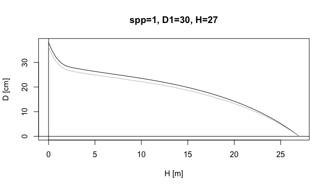

```r
plot(tree)
```

Here, the taper curve over bark (black) and under bark (grey) is drawn.

### getting BDAT-species code

BDAT has been parameterised for 36 tree species, more or less common in Germany based on about 30.000 trees. These 36 tree species are index and each posesses its own BDAT-species code. This code and the respective species name (short and long format), english species name and scientific name can be retrieved by the getSpeciesCode-function:

```r
getSpeciesCode()
```

```
##    ID kurz            lang short                long            scientific
## 1   1   Fi          Fichte    NS       Norway spruce           Picea abies
## 2   2   SF    Sitka-Fichte    SS        Sitka spruce      Picea sitchensis
## 3   3   Ta           Tanne   ESF European silver fir            Abies alba
## 4   4   KT    Kuestentanne    GF           Grand fir         Abies grandis
## 5   5  Kie          Kiefer    SP         Scotch pine      Pinus sylvestris
## 6   6   SK   Schwarzkiefer   AUP       Austrian pine           Pinus nigra
## 7   7   WK Weymouthskiefer   WEP       Weymouth pine         Pinus strobus
## 8   8   DG       Douglasie    DF         Douglas fir Pseudotsuga menziesii
## 9   9   La         Laerche   XLA               larch            Larix spp.
## 10 10   EL  Europ. Laerche   ELA      European larch         Larix decidua
## 11 11   JL    Jap. Laerche   JLA      Japanese larch       Larix kaempferi
## 12 12   Th           Thuja    RC   Western red cedar         Thuja plicata
## 13 13   Ts           Tsuga    WH     Western hemlock    Tsuga heterophylla
## 14 14   SN             sNB    XC      other conifers     Coniferales trees
```

[output cut: 22 more lines]

If the function is called without any parameter, a data.frame is returned holding the information which can be retrieved. One can alternatively specify the type of `input` and `output`. `Input` must be one of the data entries, `output` must be one of the column names.

```r
getSpeciesCode(1)
```

```
##   ID kurz   lang short          long  scientific
## 1  1   Fi Fichte    NS Norway spruce Picea abies
```

```r
getSpeciesCode("Fi")
```

```
## [1] 1
```

```r
getSpeciesCode("NS") # english abbreviation of Norway spruce
```

```
## [1] 1
```

```r
getSpeciesCode(1, "scientific")
```

```
## [1] "Picea abies"
```

```r
getSpeciesCode(c(1:36), "short")
```

```
##  [1] "NS"  "SS"  "ESF" "GF"  "SP"  "AUP" "WEP" "DF"  "XLA" "ELA" "JLA" "RC"
## [13] "WH"  "XC"  "BE"  "HBM" "OK"  "ROK" "XPO" "BPO" "AH"  "XAH" "SY"  "NOM"
## [25] "FM"  "XBI" "LI"  "AR"  "WCH" "EM"  "BL"  "WST" "SC"  "XWL" "XB"  "ROW"
```

### getting diameter in given height

The taper functions specify a curve being a function of height within tree and returns the respective diameter. Hence, one can evalutate this function at a given height and receive the diameter. There are fortran functions to return either diameter over bark and diameter under bark, but this package binds these functions together and uses a boolean parameter to switch between both.

```r
getDiameter(tree, Hx = 1.3) # return dbh
```

```
## [1] 30
```

As a default, diameter over bark is returned, but this can easily be changed:

```r
getDiameter(tree, Hx = 1.3, bark = FALSE) # return d.u.b. at 1.3m
```

```
## [1] 28.40971
```

It is possible to request diameter in several heights at once:

```r
getDiameter(tree, Hx = c(1:10))
```

```
##  [1] 31.14922 28.44761 27.57622 26.92106 26.32229 25.76090 25.21790 24.67427
##  [9] 24.11234 23.52139
```

Using this kind of call to the functions, `Hx` is evaluated for each given tree separately:

```r
tree2 <- buildTree(list(spp=1, D1=c(30, 35), H=27))
getDiameter(tree2, Hx = c(1, 2))
```

```
##          [,1]     [,2]
## [1,] 31.14922 28.44761
## [2,] 36.54927 32.92451
```

Here, a matrix is returned with one row per tree and one column per requested Hx.

An alternative way is specifying `Hx` directly inside the tree-object:

```r
tree2 <- buildTree(list(spp=1, D1=c(30, 35), H=27, Hx=c(1, 2)))
tree2
```

```
##   spp D1  H Hx  H1 D2 H2
## 1   1 30 27  1 1.3  0  0
## 2   1 35 27  2 1.3  0  0
```

```r
getDiameter(tree2)
```

```
## [1] 31.14922 32.92451
```

Here, tree2 consists of 2 rows, because the give list is internally transformed into a data frame (common rules for building data.frames apply). Finally, the object is evaluated row-wise. Because `Hx` is already given, the parameter `Hx` can be left empty.

### getting double bark thickness

Double bark thickness is that part of a diameter over bark, which is considered to consist of bark tissue. The relation between wood and bark with respect to diameter can be expressed as {double bark thickness} + {diameter under bark} = {diameter over bark}. The implemented functions originate from the works of Altherr et al. (1974, 1975, 1976, 1978 and 1979).

```r
dub <- getDiameter(tree, Hx=1.3, bark = FALSE)
dob <- getDiameter(tree, Hx=1.3, bark = TRUE)
dbt <- getBark(tree, Hx=1.3)
dub + dbt == dob
```

```
## [1] TRUE
```

Again, it is possible to either include parameter `Hx` into the tree-object or pass it separately. In the second case, an matrix is returned if Hx is longer than one.

```r
getBark(tree2, Hx = 1:5)
```

```
##          [,1]     [,2]     [,3]     [,4]     [,5]
## [1,] 1.636124 1.527308 1.491416 1.464177 1.439089
## [2,] 1.842470 1.705602 1.661812 1.629562 1.600471
```

### getting height for given diameter

The diameter-height-relation from above, where we evaluated the function for a given height-value, can also be evaluated for a given diameter. The internal function is an iterative procedure to determine height. Diameter can be specified over and under bark. Default is bark = TRUE.

```r
getHeight(tree, Dx=30) # height of diameter over bark
```

```
## [1] 1.3
```

```r
getHeight(tree, Dx=30, bark = FALSE) # height of diameter under bark == 30
```

```
## [1] 0.8916153
```

Again, it is possible to vary passing of the `Dx`-parameter: it can take one or several values, but can also be included to the tree parameter. In the first case, a cross join / cartesian product between `tree` and `Dx` is created, in the second case the `tree` object is processed *as is*.

```r
getHeight(tree2, Dx=c(30, 20, 10)) # returns value in meters
```

```
##          [,1]     [,2]     [,3]
## [1,] 1.300000 14.82080 22.65465
## [2,] 5.370549 17.27376 23.05898
```

```r
tree2$Dx = c(30, 20)
getHeight(tree2)
```

```
## [1]  1.30000 17.27376
```

As one can see, in the first case a matrix with one row per tree and one column per `Dx` is returned and in the second call, a vector with one element for each row in `tree2`.

### getting volume

The maybe most interesting function is the one returning volume. The function includes a switch to return volume with (the default) or without bark volume as well. Volume is calculated using middiameter-formula (in Germany called “Huber’sche Formel”) from 2m-sections (default), but section lengths can be varied. Additionally, it is necessary to specify the section for which volume is required. This can be done either using diameters or heights, or a mixture of both. If parameter `AB` is not given, i.e. NULL, then the function assumes coarse wood volume over bark is required (i.e. from forest floor up to diameter over bark of 7cm):

```r
getVolume(tree) # get coarse wood, which is the same as next line
```

```
## [1] 0.9168622
```

```r
getVolume(tree, AB = list(A=0, B=7), iAB=c("H", "Dob"), bark = T)
```

```
## [1] 0.9168622
```

One can precisely specify the section for which volume under or over bark is required:

```r
# volume including bark between height 1m and 2m
getVolume(tree2, AB=list(A=1, B=2))
```

```
## [1] 0.06184182 0.08197092
```

```r
# volume excluding bark between 30 and 7cm in diameter over bark
getVolume(tree2, AB=list(A=30, B=7), iAB="dob", bark = F)
```

```
## [1] 0.7153726 0.6583801
```

The section length for which middiameter-formula is applied is 2m as a default. It is possible to change that behaviour by setting parameter `sl` inside the `AB`-argument:

```r
# again: coarse wood volume
getVolume(tree)
```

```
## [1] 0.9168622
```

```r
# identical
getVolume(tree, AB=list(A=0.27, B=7, sl=2), iAB=c("H", "Dob"), bark=F)
```

```
## [1] 0.7892534
```

```r
# using sl=0.1, that is section length for volume calculation set to be 0.1m
getVolume(tree, AB=list(A=0.27, B=7, sl=0.1), iAB=c("H", "Dob"), bark=F)
```

```
## [1] 0.7971188
```

If one wants to get the volume for several sections of a tree, one could either build a suited data.frame on its own, repeating the tree attributes and adjusting the `A`and `B` values as needed. The more elegant way is to let the functions do that work for you. In the easiest case, we saw that already in the example above, specifying one tree and one section, where the function returns exactly one volume. Internally, the `AB` data is merged to the tree data by a cross join (or cartesion product), hence we can make use of that behaviour by defining several sections at once:

```r
getVolume(tree, AB=list(A=0:9, B=1:10))
```

```
##  [1] 0.09056835 0.06184182 0.06128590 0.05816483 0.05563769 0.05319688
##  [7] 0.05102357 0.04886994 0.04674566 0.04458112
```

```r
getVolume(tree = tree2, AB=list(A=0:9, B=1:10))
```

```
##            [,1]       [,2]       [,3]       [,4]       [,5]       [,6]
## [1,] 0.09056835 0.06184182 0.06128590 0.05816483 0.05563769 0.05319688
## [2,] 0.12786366 0.08197092 0.08171326 0.07714033 0.07358742 0.07018656
##            [,7]       [,8]       [,9]      [,10]
## [1,] 0.05102357 0.04886994 0.04674566 0.04458112
## [2,] 0.06725162 0.06435400 0.06151795 0.05862010
```

### getting biomass

Beside getting volume section information, there is a function to get total aboveground biomass. These biomass-functions were fitted independently of the parameterisation of BDAT and were developed in preparation of the german NFI3. These functions are based on 983 analysed trees of a subset of species only. The other species are either fit at a synthetical data set or in worst case subsumed to other species. These functions are the official ones used during reporting of results of the NFI3.

The call is identical to the already shown pattern:

```r
getBiomass(tree)
```

```
## [1] 390.8751
```

```r
getBiomass(list(spp=1, D1=30, H=27, D2=c(23, 24, 25)))
```

```
## [1] 350.5039 375.2445 400.5624
```

### getting assortments

One very nice feature of the BDAT program library is its ability to use the presented functions to simulate roundwoods from given trees. For that purpose a separate function was written, which is called via `getAssortment()`. Similarly to other functions, it requires data of one or more trees and optionally parameters to control the sorting process. There are quite a few parameters to be specified. It’s easiest to show that using some examples:

```r
getAssortment(tree2) # using standard assortment parameters
```

```
##    tree No Sort height    length      midD      topD        Vol
## 1     1  1    X   0.00  0.000000  0.000000  0.000000 0.00000000
## 2     1  2  Sth   0.27 20.000000 21.250875 12.429831 0.70937115
## 3     1  3   Ab   0.00  0.000000  0.000000  0.000000 0.00000000
## 4     1  4  Ind  20.47  1.000000 11.460602 10.725959 0.01031584
## 5     1  5 nvDh  21.47  2.717499  8.529173  5.998856 0.01552648
## 6     2  1    X   0.00  0.000000  0.000000  0.000000 0.00000000
## 7     2  2  Sth   0.27 20.000000 24.499969 13.956373 0.94286811
## 8     2  3   Ab   0.00  0.000000  0.000000  0.000000 0.00000000
## 9     2  4  Ind  20.47  1.000000 12.778620 11.893189 0.01282501
## 10    2  5 nvDh  21.47  2.904999  9.106683  5.990857 0.01892153
```

By default, a data.frame is returned with one row for each tree and roundwood piece. It keeps information about the roundwood foot position inside the stem, its length (without add-on), mid-diameter under bark (midD), top-diameter under bark (topD) and the respective volume under bark. The standard assortments comprise stem-wood (Sth), second length stem wood (Ab, after optionally specified cutting diameter for Sth or after transportation-cut, i.e. 20m), industrial roundwood (Ind) and residual coarse wood (nvDh, between cutting diameter for Ind and 7cm over bark). Assortment X is unusuable wood at the stem foot.

If one is interested in raw BDAT return, one can specify `value='raw'`:

```r
getAssortment(tree2, value = "raw") # usually of little interest...
```

```
## $n
## [1] 2
##
## $BDATArtNr
## [1] 1 1
##
## $D1
## [1] 30 35
## attr(,"Csingle")
## [1] TRUE
##
## $H1
## [1] 1.3 1.3
## attr(,"Csingle")
## [1] TRUE
##
## $D2
## [1] 0 0
## attr(,"Csingle")
## [1] TRUE
##
## $H2
## [1] 0 0
## attr(,"Csingle")
## [1] TRUE
##
## $H
## [1] 27 27
## attr(,"Csingle")
## [1] TRUE
##
## $lX
## [1] 0 0
## attr(,"Csingle")
## [1] TRUE
##
## $Hkz
## [1] 0 0
##
## $Skz
```

[output cut: 62 more lines]

[output not shown]

Other options are also available like ‘Vol’ (Volume), ‘Skl’ (Stärkeklassen, i.e. diameter classes), ‘Fix’ (fixed length assortments, if specified) and ‘LDSort’ (an added feature w.r.t. the original BDAT Fortran code, keeping length and diameter of the assortments, which was missing in the original BDAT library, hence only available in rBDAT!), which return a subset of the raw BDAT return value. The default is ‘merge’ which produces an aggregated data.frame of relevant information about the roundwoods produced for each tree.

As said before, assortment rules can be specified using several parameters, which in detail are given in the help file. Some examples follow:

```r
getAssortment(tree, sort=list(Az=15)) # minimum diameter o.b. for assortments
```

```
##   tree No Sort height    length     midD      topD        Vol
## 1    1  1    X  0.000  0.000000  0.00000  0.000000 0.00000000
## 2    1  2  Sth  0.270 19.100000 21.51180 13.584801 0.69418710
## 3    1  3   Ab  0.000  0.000000  0.00000  0.000000 0.00000000
## 4    1  4  Ind  0.000  0.000000  0.00000  0.000000 0.00000000
## 5    1  5 nvDh 19.561  4.626499 10.10419  5.998856 0.03709757
```

```r
getAssortment(tree, sort=list(Az=15, Hsh=10)) # Hsh= max. height of sawlog quality
```

```
##   tree No Sort height length     midD      topD        Vol
## 1    1  1    X  0.000 0.0000  0.00000  0.000000 0.00000000
## 2    1  2  Sth  0.270 9.6000 24.09461 21.483158 0.43772444
## 3    1  3   Ab  0.000 0.0000  0.00000  0.000000 0.00000000
## 4    1  4  Ind  9.966 9.0000 18.60693 14.073549 0.24472708
## 5    1  5 nvDh 18.966 5.2215 10.56425  5.998856 0.04576806
```

Additionally one can specify a fixed length assortment at stem foot, which is cut before sawlogs.

```r
## fixN = number of roundwood pieces
## fixL = length of roundwood pieces in m
## fixA = absolute length addition (good for measure) in cm
## fixR = relative length addition in %
## fixZ = minimum cutting diameter for this assortment (Z=Zopf) in cm
getAssortment(tree, sort=list(Az=15, fixN=2, fixL=4, fixA=10, fixZ=20))
```

```
##   tree No  Sort    height  length     midD      topD       Vol
## 1    1  1     X  0.000000  0.0000  0.00000  0.000000 0.0000000
## 2    1  2   Sth  8.470001 10.9000 19.04127 13.584801 0.3103904
## 3    1  3    Ab  0.000000  0.0000  0.00000  0.000000 0.0000000
## 4    1  4   Ind  0.000000  0.0000  0.00000  0.000000 0.0000000
## 5    1  5  nvDh 19.479000  4.7085 10.16843  5.998856 0.0382367
## 6    1  6 Fix01  0.270000  4.0000 25.86922 24.547409 0.2102405
## 7    1  7 Fix02  4.370000  4.0000 23.40202 22.309429 0.1720507
```

In case the considered tree exhibits rotten/decaying wood at stem foot, this can also be specified (in german termed X-Holz):

```r
getAssortment(tree, sort=list(lX=1.4)) # remove 1.4m from stump upwards
```

```
##   tree No Sort height    length      midD      topD        Vol
## 1    1  1    X   0.27  1.400000 28.892862 26.715826 0.09179077
## 2    1  2  Sth   1.67 20.000000 20.387375 10.421552 0.65289372
## 3    1  3   Ab   0.00  0.000000  0.000000  0.000000 0.00000000
## 4    1  4  Ind   0.00  0.000000  0.000000  0.000000 0.00000000
## 5    1  5 nvDh  21.87  2.317499  8.178885  5.998856 0.01217580
```

Additionally, one can plot the taper curve and include the assortments:

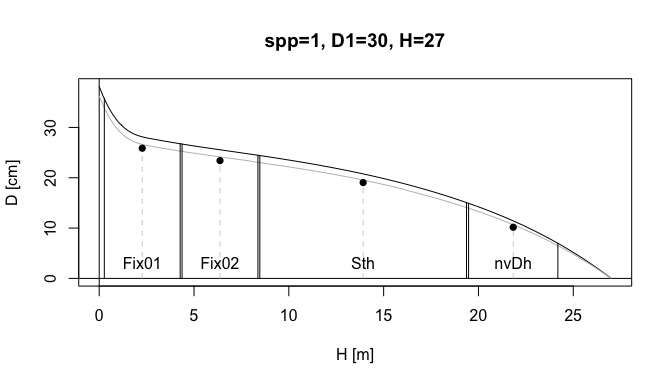

```r
assort <- getAssortment(tree, sort=list(Az=15, fixN=2, fixL=4, fixA=10, fixZ=20))
plot(tree, assort=assort)
```

#### using more than one assortment specification

`buildTree` uses the parameters `tree` and `vars` which are merged by a cross join / cartesian product. Hence, if assortment specifications are extended to a length bigger one, the function should return an estimated assortment for each tree and specified assortment. Let’s check that:

```r
getAssortment(tree, sort = list(Az=c(10, 7)))
```

```
##    tree No Sort height     length      midD      topD         Vol
## 1     1  1    X   0.00  0.0000000  0.000000  0.000000 0.000000000
## 2     1  2  Sth   0.27 20.0000000 21.250875 12.429831 0.709371150
## 3     1  3   Ab   0.00  0.0000000  0.000000  0.000000 0.000000000
## 4     1  4  Ind  20.47  2.0000000 10.725959  9.139494 0.018071413
## 5     1  5 nvDh  22.47  1.7174988  7.639552  5.998856 0.007872671
## 6     2  1    X   0.00  0.0000000  0.000000  0.000000 0.000000000
## 7     2  2  Sth   0.27 20.0000000 21.250875 12.429831 0.709371150
## 8     2  3   Ab   0.00  0.0000000  0.000000  0.000000 0.000000000
## 9     2  4  Ind  20.47  3.0000000  9.953113  7.379699 0.023341509
## 10    2  5 nvDh  23.47  0.7174988  6.702212  5.998856 0.002531322
```

```r
getAssortment(tree2, sort = list(Az=c(10, 7)))
```

```
##    tree No Sort height     length      midD      topD         Vol
## 1     1  1    X   0.00  0.0000000  0.000000  0.000000 0.000000000
## 2     1  2  Sth   0.27 20.0000000 21.250875 12.429831 0.709371150
## 3     1  3   Ab   0.00  0.0000000  0.000000  0.000000 0.000000000
## 4     1  4  Ind  20.47  2.0000000 10.725959  9.139494 0.018071413
## 5     1  5 nvDh  22.47  1.7174988  7.639552  5.998856 0.007872671
## 6     2  1    X   0.00  0.0000000  0.000000  0.000000 0.000000000
## 7     2  2  Sth   0.27 20.0000000 24.499969 13.956373 0.942868114
## 8     2  3   Ab   0.00  0.0000000  0.000000  0.000000 0.000000000
## 9     2  4  Ind  20.47  2.0000000 11.893189 10.009459 0.022218592
## 10    2  5 nvDh  22.47  1.9049988  8.071947  5.990857 0.009748576
## 11    3  1    X   0.00  0.0000000  0.000000  0.000000 0.000000000
## 12    3  2  Sth   0.27 20.0000000 21.250875 12.429831 0.709371150
## 13    3  3   Ab   0.00  0.0000000  0.000000  0.000000 0.000000000
## 14    3  4  Ind  20.47  3.0000000  9.953113  7.379699 0.023341509
## 15    3  5 nvDh  23.47  0.7174988  6.702212  5.998856 0.002531322
## 16    4  1    X   0.00  0.0000000  0.000000  0.000000 0.000000000
## 17    4  2  Sth   0.27 20.0000000 24.499969 13.956373 0.942868114
## 18    4  3   Ab   0.00  0.0000000  0.000000  0.000000 0.000000000
## 19    4  4  Ind  20.47  3.0000000 10.970320  7.971595 0.028356308
## 20    4  5 nvDh  23.47  0.9049988  6.997648  5.990857 0.003480503
```

Here, the first call returns the estimated assortments for both assortment specifications, the tree order inside the resulting object is clear: tree 1 uses Az=10 and tree 2 uses Az=7. In the second call, the order is the same, although this is not as clear as in the first example.

### more advanced specification of trees

As shown, a tree is specified by its species code, its dbh and height. If done so, this assumes a predefined diameter in 30% of tree height, which in turn defines the taper form or the relation between diameter in 30% and 5% of the tree height. But easily, this can be changed: the BWI-equivalent taper form can be specified using H2=50. The D2 and H2 parameter can take a very flexible parameterisation being diameter and heights but also quantiles of the q03-distribution (H2) or the q03-parameter itself (D2). q03 is the quotient of diameter in 30% of three height and in 5% of tree height. Hence, quite a variety of taper forms can be represented. All BDAT-functions respond sensitively to this fourth parameter.

```r
tree <- buildTree(tree = list(spp=1, D1=30, H=27, H2=c(30, 50, 99, 0),
                              D2=c(0, 0, 0, -0.8), Hx=0.3*27))
str(tree)
```

```
## Classes 'datBDAT' and 'data.frame':  4 obs. of  7 variables:
##  $ spp: num  1 1 1 1
##  $ D1 : num  30 30 30 30
##  $ H  : num  27 27 27 27
##  $ H2 : num  30 50 99 0
##  $ D2 : num  0 0 0 -0.8
##  $ Hx : num  8.1 8.1 8.1 8.1
##  $ H1 : num  1.3 1.3 1.3 1.3
```

```r
getDiameter(tree) # Hx specified beforehand being 30% of tree height
```

```
## [1] 23.19664 24.00090 27.59044 23.84774
```

With the getForm-function, one can specify trees mimicking the mean sample trees from different inventories. This function returns the expected q03 of a given diameter-height-class, here of dbh=30 and h=27:

```r
getForm(tree[1,], inv=c(1, 2, 3, 4))
```

```
## [1] 0.8049681 0.7996023 0.7913954 0.8107125
```